# BonusAssignment2_Seshadri

Sri Seshadri

3/11/2018

# Objective:

Study the effect on coefficients of a model due to repeated resampling of training and validation samples.

# Executive Summary

The coefficients of a model trained on, one time sampling of training data, is biased. Its is necessary to train and test the model in multiple cross validated samples to get an unbiased estimate of the coefficients.

# Analysis

## Explore and Set up the data set

The structure of GermanCredit data set is explored below. It looks like there are several binary variables that are of the type numeric. The binary variables are converted into factors. Also there are couple of features that have only one unique value, those featuers are removed from the data for modeling. It’ll also be useful to scale and center the data for easier plotting of multiple coefficients in the same plot

```r
data("GermanCredit")
skimr::skim(GermanCredit)
```

[output not shown]

[output cut: 669 more lines]

```r
integerVars <- GermanCredit  %>% dplyr::select_if(is.integer) %>% names
Vars <- colnames(GermanCredit)
tobeConvertedVars <- Vars[!Vars %in% integerVars]

GermanCredit[tobeConvertedVars] <- lapply(GermanCredit[tobeConvertedVars], factor)
UniqueVars <- Vars[caret::nearZeroVar(GermanCredit,uniqueCut = 0)]
Vars2select <- Vars[!Vars %in% UniqueVars]
GermanCredit <- GermanCredit %>% dplyr::select(!!Vars2select)

trans <- caret::preProcess(GermanCredit,center = T, scale = T)
GermanCredit <- predict(trans, GermanCredit)
```

The GermanCredit data in caret package is split into training and test in the ratio 63.2:36.8 repeatedly for 1000 times. The rsample package is used to split the data iteratively.

The the number of rows of data for each split is verified in figure 1.

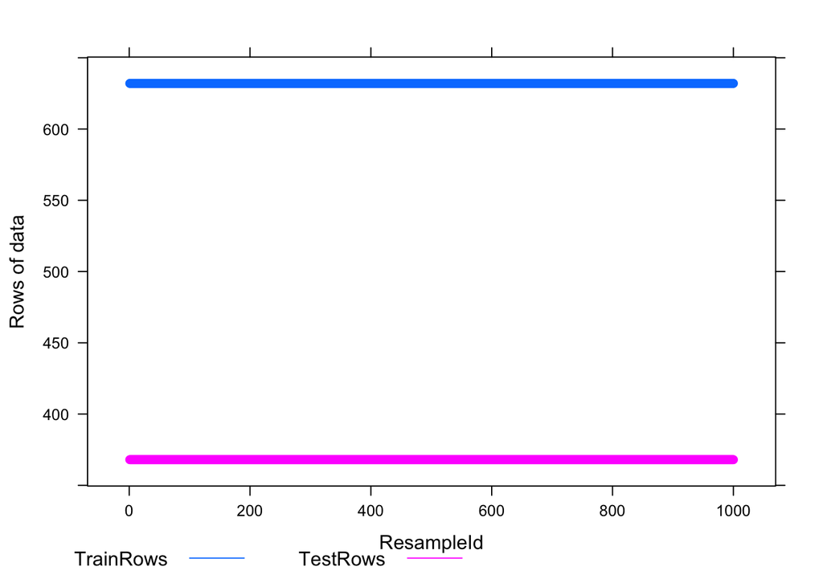

Verify split

```r
set.seed(1)
# Data sampled without replacement

samples <- rsample::mc_cv(data = GermanCredit,prop = 0.632,times = 1000)

# Verify the dimensions of the first of the 1000 splits

SampleVerification <- purrr::map_df(1:1000,.f = function(x) data.frame(ResampleId = x,TrainRows = nrow(analysis(samples$splits[[x]])), TestRows = nrow(assessment(samples$splits[[x]]))) )

lattice::xyplot(TrainRows + TestRows ~ ResampleId,data = SampleVerification,ylab = "Rows of data",auto.key=list(space="bottom", columns=4, cex.title=1,lines=TRUE, points=FALSE, box = T))
```

## Linear model fits and evaluation.

Linear model is fit on the training sets and the model is evaluated on the test sets for each of the 1000 train-test samples. Those variables that have only one unique value are removed as predictors.

```r
# Function to get model stats
ModelSummaries <- function(split){
  # get the train and test sets from the split
  Train <- rsample::analysis(split$splits[[1]])
  Test <- rsample::assessment(split$splits[[1]])
  Vars <- colnames(Train)
  # get variables that have only one unique value and remove them
  UniqueVars <- caret::nearZeroVar(Train,uniqueCut = 0)
  if(length(UniqueVars) > 0){
    Train <- Train[,UniqueVars*-1]
    Test <- Test[,UniqueVars*-1]
  }


  # linear model fit
  lm.fit <- lm(Amount ~ ., data = Train)
  coefs <- coefficients(lm.fit)
  AdjR2.Train <- summary(lm.fit)$adj.r.squared
  yPred <- predict(lm.fit,newdata = Test)
  R2.test <- cor(yPred,Test$Amount)^2
  return(list(Betas = coefs,Train.R2 = AdjR2.Train, Test.R2 = R2.test))
}

ModelStats <- purrr::map(1:1000,function(x) ModelSummaries(samples[x,]))

# Check if named vectors of Beta coefficients are the same for all the 1000 splits
lengthVer <- sapply(1:1000,function(x) names(ModelStats[[x]]$Betas))
test2 <- sapply(1:60, function(x) {length(unique(lengthVer[x,]))})
#plot(test2)

# Retrieve Beta coefficents as dataframe

df.coef <- sapply(1:1000, function(x){ModelStats[[x]]$Betas})
df.coef <- t(df.coef)

Rsquared <- data.frame(Train = train <- sapply(1:1000, function(x){ModelStats[[x]]$Train.R2}),
                       Test = sapply(1:1000, function(x){ModelStats[[x]]$Test.R2}))

Rsquared <- Rsquared %>% mutate(PercFall = (Train - Test)/Train)
```

Figure 2 shows the scaled coefficients of the predictors.

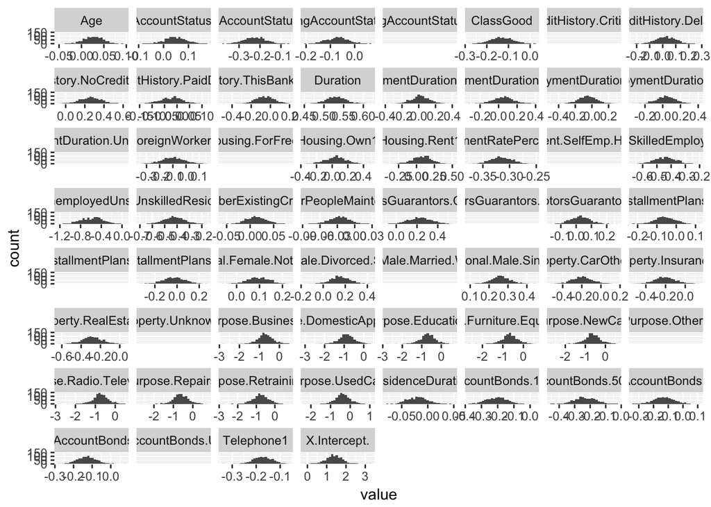

Scaled Coefficients plot

```r
df.coef <- data.frame(df.coef)
df.coef.plotdf <- tidyr::gather(df.coef)
ggplot(data = df.coef.plotdf, mapping = aes(x=value)) + geom_histogram() + facet_wrap(~key, scales = 'free_x')
```

Figure 3 shows the distribution of R-Squared of Training and Test data and as well the % fall in R-Squared from training to test.

It can be seen that the % Fall in R Squared is within a range of -20% to 30%.

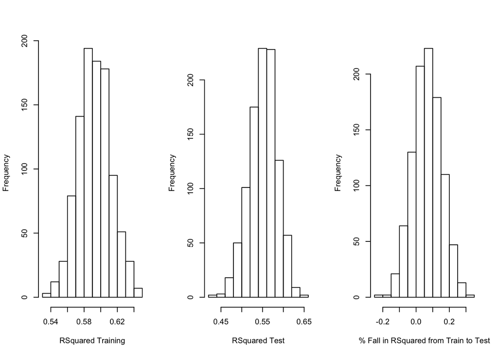

```r
par(mfrow=c(1,3))
hist(Rsquared$Train,xlab = "RSquared Training", main="")
hist(Rsquared$Test,xlab = "RSquared Test", main="")
hist(Rsquared$PercFall, xlab = "% Fall in RSquared from Train to Test", main="")
```

```r
library(Rmisc)
Stats <- data.frame(t(sapply(1:60, function(x){CI(df.coef[,x])}))) %>% dplyr::mutate(Predictor = colnames(df.coef)) %>%
  dplyr::select(Predictor,lower,mean,upper)

trainSamples <- sample(1000,632)
#nearZeroVar(GermanCredit[train,],uniqueCut = 0)
lmfit.once <- lm(Amount ~ ., data = GermanCredit[trainSamples,])
coefs.omce <- coef(lmfit.once)
Stats <- Stats %>% dplyr::mutate(OneTimeSplitCoef = coefs.omce, WithinCI = if_else(coefs.omce >= lower & coefs.omce <= upper,"Within","Outside"))

knitr::kable(Stats, caption = "Comparison of single coefficient to averge of 1000 fits")
```

Comparison of single coefficient to averge of 1000 fits

| Predictor | lower | mean | upper | OneTimeSplitCoef | WithinCI |
| --- | --- | --- | --- | --- | --- |
| X.Intercept. | 1.3610675 | 1.3883982 | 1.4157290 | 1.0076342 | Outside |
| Duration | 0.5293622 | 0.5309347 | 0.5325073 | 0.4872938 | Outside |
| InstallmentRatePercentage | -0.3165723 | -0.3153660 | -0.3141596 | -0.3045645 | Outside |
| ResidenceDuration | -0.0205579 | -0.0193493 | -0.0181408 | -0.0012570 | Outside |
| Age | 0.0255229 | 0.0268692 | 0.0282155 | 0.0187196 | Outside |
| NumberExistingCredits | 0.0110226 | 0.0123172 | 0.0136119 | 0.0197262 | Outside |
| NumberPeopleMaintenance | -0.0275179 | -0.0264781 | -0.0254383 | -0.0548516 | Outside |
| Telephone1 | -0.1750750 | -0.1726407 | -0.1702064 | -0.1299213 | Outside |
| ForeignWorker1 | -0.1040195 | -0.0986412 | -0.0932629 | -0.0122258 | Outside |
| ClassGood | -0.1336153 | -0.1305027 | -0.1273901 | -0.0976242 | Outside |
| CheckingAccountStatus.lt.01 | -0.0748525 | -0.0719788 | -0.0691051 | 0.0200919 | Outside |
| CheckingAccountStatus.0.to.2001 | 0.0447519 | 0.0473957 | 0.0500395 | 0.1019934 | Outside |
| CheckingAccountStatus.gt.2001 | -0.2290817 | -0.2258868 | -0.2226919 | -0.2629068 | Outside |
| CheckingAccountStatus.none1 | NA | NA | NA | NA | NA |
| CreditHistory.NoCredit.AllPaid1 | 0.2535960 | 0.2606260 | 0.2676560 | 0.0358525 | Outside |
| CreditHistory.ThisBank.AllPaid1 | -0.0628903 | -0.0569821 | -0.0510739 | -0.0489794 | Outside |
| CreditHistory.PaidDuly1 | -0.0244654 | -0.0217219 | -0.0189783 | 0.0864416 | Outside |
| CreditHistory.Delay1 | 0.0202810 | 0.0249907 | 0.0297005 | 0.1181631 | Outside |
| CreditHistory.Critical1 | NA | NA | NA | NA | NA |
| Purpose.NewCar1 | -0.6661461 | -0.6420297 | -0.6179133 | -0.6664775 | Outside |
| Purpose.UsedCar1 | -0.4125948 | -0.3884939 | -0.3643930 | -0.2902017 | Outside |
| Purpose.Furniture.Equipment1 | -0.6794603 | -0.6552790 | -0.6310976 | -0.7004469 | Outside |
| Purpose.Radio.Television1 | -0.7600349 | -0.7360964 | -0.7121579 | -0.7989457 | Outside |
| Purpose.DomesticAppliance1 | -0.9098339 | -0.8848707 | -0.8599074 | -0.9329383 | Outside |
| Purpose.Repairs1 | -0.6422480 | -0.6173233 | -0.5923987 | -0.8524553 | Outside |
| Purpose.Education1 | -0.7181040 | -0.6938231 | -0.6695422 | -0.6701855 | Within |
| Purpose.Retraining1 | -0.7903655 | -0.7640032 | -0.7376408 | -1.0415600 | Outside |
| Purpose.Business1 | -0.7283467 | -0.7041555 | -0.6799643 | -0.7783022 | Outside |
| Purpose.Other1 | NA | NA | NA | NA | NA |
| SavingsAccountBonds.lt.1001 | -0.1316095 | -0.1284673 | -0.1253251 | -0.0652545 | Outside |
| SavingsAccountBonds.100.to.5001 | -0.2103486 | -0.2063924 | -0.2024363 | -0.2305228 | Outside |
| SavingsAccountBonds.500.to.10001 | -0.2353459 | -0.2309910 | -0.2266360 | -0.1632795 | Outside |
| SavingsAccountBonds.gt.10001 | -0.1345730 | -0.1303231 | -0.1260732 | -0.0734524 | Outside |
| SavingsAccountBonds.Unknown1 | NA | NA | NA | NA | NA |
| EmploymentDuration.lt.11 | 0.0320726 | 0.0387220 | 0.0453713 | 0.0887161 | Outside |
| EmploymentDuration.1.to.41 | 0.0139163 | 0.0206067 | 0.0272970 | 0.0880706 | Outside |
| EmploymentDuration.4.to.71 | 0.0470244 | 0.0540457 | 0.0610669 | 0.2346389 | Outside |
| EmploymentDuration.gt.71 | -0.0595789 | -0.0527727 | -0.0459665 | 0.0612719 | Outside |
| EmploymentDuration.Unemployed1 | NA | NA | NA | NA | NA |
| Personal.Male.Divorced.Seperated1 | 0.1474485 | 0.1528003 | 0.1581521 | 0.2172886 | Outside |
| Personal.Female.NotSingle1 | 0.0909682 | 0.0938667 | 0.0967652 | 0.0448338 | Outside |
| Personal.Male.Single1 | 0.2588820 | 0.2619492 | 0.2650164 | 0.2710714 | Outside |
| Personal.Male.Married.Widowed1 | NA | NA | NA | NA | NA |
| OtherDebtorsGuarantors.None1 | 0.0228669 | 0.0267009 | 0.0305350 | 0.0014942 | Outside |
| OtherDebtorsGuarantors.CoApplicant1 | 0.2226994 | 0.2291624 | 0.2356255 | 0.3369058 | Outside |
| OtherDebtorsGuarantors.Guarantor1 | NA | NA | NA | NA | NA |
| Property.RealEstate1 | -0.2927526 | -0.2862939 | -0.2798351 | -0.2358026 | Outside |
| Property.Insurance1 | -0.2098111 | -0.2031548 | -0.1964984 | -0.1448284 | Outside |
| Property.CarOther1 | -0.2010101 | -0.1944734 | -0.1879366 | -0.0916335 | Outside |
| Property.Unknown1 | NA | NA | NA | NA | NA |
| OtherInstallmentPlans.Bank1 | -0.0624438 | -0.0592244 | -0.0560049 | -0.0850008 | Outside |
| OtherInstallmentPlans.Stores1 | -0.0334157 | -0.0275384 | -0.0216611 | -0.0317454 | Within |
| OtherInstallmentPlans.None1 | NA | NA | NA | NA | NA |
| Housing.Rent1 | 0.0666029 | 0.0746474 | 0.0826919 | 0.0461640 | Outside |
| Housing.Own1 | 0.0369494 | 0.0448396 | 0.0527299 | 0.0792720 | Outside |
| Housing.ForFree1 | NA | NA | NA | NA | NA |
| Job.UnemployedUnskilled1 | -0.5949737 | -0.5818403 | -0.5687068 | -0.3422740 | Outside |
| Job.UnskilledResident1 | -0.4269291 | -0.4219083 | -0.4168875 | -0.5008756 | Outside |
| Job.SkilledEmployee1 | -0.4456681 | -0.4411288 | -0.4365895 | -0.4424048 | Within |
| Job.Management.SelfEmp.HighlyQualified1 | NA | NA | NA | NA | NA |

```r
table(Stats$WithinCI)
```

```
##
## Outside  Within
##      46       3
```

# Conclusion